# Modelling Interventions in Odin

Keywords

Infectious Disease Modelling, Odin, Interventions

# Odin

### SIR Model

We will first review the `SIR` model covered earlier in the summer school. The model can be represented using flow diagrams as shown in Figure 1 or defined by a sequence of ordinary differential equations (ODEs)as shown below: The differential equations for the model are:
$$\begin{align*}
\frac{dS}{dt} &= -\beta S I \\
\frac{dI}{dt} &= \beta S I - \gamma I \\
\frac{dR}{dt} &= \gamma I
\end{align*}$$

[figure not shown]

Figure 1: SIR model diagram

The parameters of the model are:

- $\beta$ - the transmission rate
- $\gamma$ - the rate of recovery

We will assume that on average a person recovers in 5 days, which means $\gamma = \dfrac{1}{5} = 0.2 \text{ per day}$.

We know that for SIR model $R_0 = \beta \times \dfrac{N}{\gamma},$ where `N` is the population of the country. Assume Singapore, i.e., $N=5.7e6$

If we are modelling a disease with $R_0=2.5$, then we get $\beta = 2.5 \times \dfrac{0.2}{5700000} = 8.77 \times 10^{-8} \text{ per(day} \times \text{person)}$.

We can now use these values to simulate the SIR model. We will use the `odin` package to do this. The code for model is shown below Listing 1.

Listing 1: Implementation of the SIR model in odin

```r
library(odin)
library(tidyverse)

# define the model
sir_ode <- odin::odin({
  # Derivatives
  deriv(S) <- -beta * S * I
  deriv(I) <- beta * S * I  - gamma * I
  deriv(R) <- gamma * I

  # Initial conditions
  initial(S) <- N_ini - I_ini
  initial(I) <- I_ini
  initial(R) <- 0

  # user defined values
  # user defined values can be given another value
  # while initializing
  N_ini <- user(5700000)
  I_ini <- user(1)

  # user defined parameters
  beta <- user(8.77e-8)
  gamma <- user(0.2)
})
```

Refer to Listing 2 for code to run the model and Figure 2 for the output.

Listing 2: Running SIR model

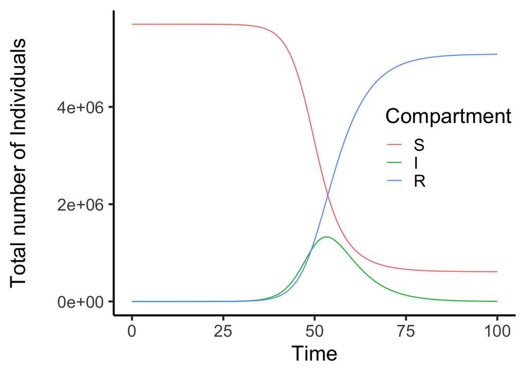

Figure 2: Simulation of the SIR model for 100 days

```r
# initialize model
sir_mod <- sir_ode$new()
# how long to run
times <- seq(0,100)
# run the model
sir_out <- sir_mod$run(times)
# extracting data as tibble
df_sir_out <- as.data.frame(sir_out)
# plotting data
p_sir <- df_sir_out %>%
  ggplot(aes(x = t, color = name)) +
  geom_line(aes(y=S, color="S"), alpha = 0.95) +
  geom_line(aes(y=I, color="I"), alpha = 0.95) +
  geom_line(aes(y=R, color="R"), alpha = 0.95) +
  scale_colour_discrete(limits = c("S", "I", "R")) +
  xlab("Time") +
  ylab("Total number of Individuals\n") +
  labs(color="Compartment") +
  theme_classic(base_size = 20) +
  theme(legend.justification = 0, legend.position = c(0.65, 0.55))
p_sir
```

### SEIR-Birth-Death Model

An `SEIR` model with birth and deaths is shown in Figure 3. Here, we have assumed that the birth and death rates are the equal.

[figure not shown]

Figure 3: SEIR model diagram

The modified differential equations for the model are:

$$\begin{align*}
\frac{dS}{dt} &= -\beta IS - \mu S + \mu (S+E+I+R) \\
\frac{dE}{dt} &= \beta IS - \lambda E - \mu E \\
\frac{dI}{dt} &= \lambda E - \gamma I - \mu I \\
\frac{dR}{dt} &= \gamma I - \mu R
\end{align*}$$

The parameters of the model are:

- $\beta$ - the transmission rate
- $\lambda$ - the rate of progression from the latent to the infectious state
- $\gamma$ - the rate of recovery
- $\mu$ - the rate of birth and death

There are two new parameters in this model when compared to the previous model.

The life expectancy in Singapore is 83 years[1].which gives us a death rate of $\mu = \dfrac{1}{(83.5 \times 365)} = 3.30 \times 10^{-5} \text{ per day}$.

For $\lambda$, we assume people that people remain on average latent for 2 days, hence $\lambda = \dfrac{1}{2} = 0.5 \text{ per day}$.

The code for model is shown below Listing 3. The Figure 4 shows the simulation of the epidemic as per the model.

Listing 3: Implementation of the SEIR model in odin

```r
# define the model
seir_ode <- odin::odin({
  # Derivatives
  deriv(S) <- -beta * S * I + mu*N  -mu*S
  deriv(E) <- beta * S * I - lambda * E - mu *E
  deriv(I) <- lambda * E  - gamma * I - mu * I
  deriv(R) <- gamma * I - mu * R

  # Total Population
  N <- S + E + I + R

  # Initial conditions
  initial(S) <- N_ini - I_ini
  initial(I) <- I_ini
  initial(R) <- 0
  initial(E) <- 0

  # user defined values
  # user defined values can be given another value
  # while initializing
  N_ini <- user(5700000)
  I_ini <- user(1)

  # user defined parameters
  beta <- user(8.77e-8)
  gamma <- user(0.2)
  lambda <- user(0.5)
  mu <- user(3.3e-5)
})
```

Listing 4: Run SEIR model

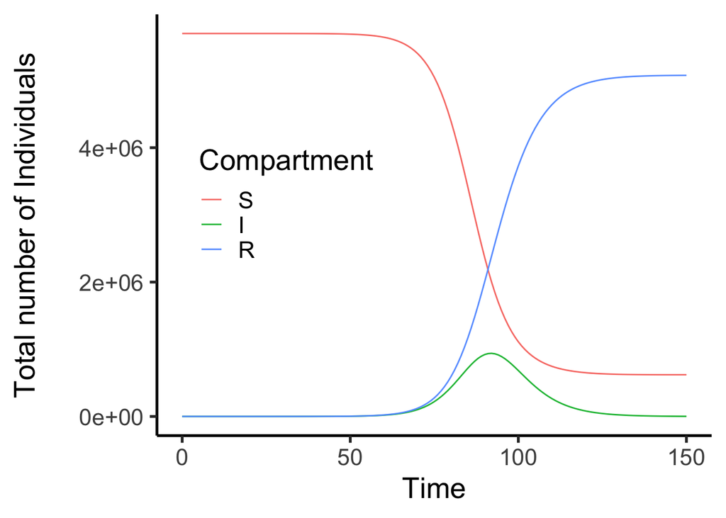

Figure 4: Simulation of the SEIR model for 150 days

```r
# initialize model
seir_mod <- seir_ode$new()
# how long to run
times <- seq(0,150)
# run the model
seir_out <- seir_mod$run(times)
# extracting data as tibble
df_seir_out <- as.data.frame(seir_out)
# plotting data
p_seir <- df_seir_out %>%
  ggplot(aes(x = t, color = name)) +
  geom_line(aes(y=S, color="S"), alpha = 0.95) +
  geom_line(aes(y=I, color="I"), alpha = 0.95) +
  geom_line(aes(y=R, color="R"), alpha = 0.95) +
  scale_colour_discrete(limits = c("S", "I", "R")) +
  xlab("Time") +
  ylab("Total number of Individuals\n") +
  labs(color="Compartment") +
  theme_classic(base_size = 20) +
  theme(legend.justification = 0, legend.position = c(0.05, 0.55))
p_seir
```

**Liberty taken**

### Units of parameters

From here on, we will take liberty of not mentioning the units of the parameters.

### Flow diagrams

We will only write differential equations from now.

# Shock-Intervention

One of the most common ways of modelling interventions is doing a scenario analysis by assuming that your intervention will reduce the contacts by a constant factor.

Let us first write the model equations for this system, assuming our base model is the one discussed in Figure 3.

$$\begin{align*}
\frac{dS}{dt} &= -\beta(t) IS - \mu S + \mu (S+E+I+R) \\
\frac{dE}{dt} &= \beta(t) IS - \lambda E - \mu E \\
\frac{dI}{dt} &= \lambda E - \gamma I - \mu I \\
\frac{dR}{dt} &= \gamma I - \mu R
\end{align*}$$

Where the transmission rate $\beta(t)$ changes at a specific time $t_1$ due to an intervention:

$$\begin{align*}
\beta(t) =
\begin{cases}
\beta_0 & \text{if } t < t_1 \\
\beta_1 & \text{if } t \geq t_1
\end{cases}
\end{align*}$$

The code for model is shown below Listing 5, assuming we do an intervention at $t_1=80$ and it reduces contacts by $20\%$. The Figure 5 shows the simulation of the epidemic as per the model.

```r
# define the model
tv_ode <- odin::odin({
  ## Derivatives
  deriv(S) <- -beta * S * I + mu*N  -mu*S
  deriv(E) <- beta * S * I - lambda * E - mu *E
  deriv(I) <- lambda * E  - gamma * I - mu * I
  deriv(R) <- gamma * I - mu * R

  ## Time-varying reproduction number Rt
  beta <- if (t < change_time) beta_0 else beta_0 * reduction

  # Total Population
  N <- S + E + I + R

  # Initial conditions
  initial(S) <- N_ini - I_ini
  initial(I) <- I_ini
  initial(R) <- 0
  initial(E) <- 0

  # user defined values
  # user defined values can be given another value
  # while initializing
  N_ini <- user(5700000)
  I_ini <- user(1)

  # user defined parameters
  beta_0 <- user(8.77e-8)
  gamma <- user(0.2)
  lambda <- user(0.5)
  mu <- user(3.3e-5)
  reduction <- user(0.8) # Reduction in R0 due to interventions
  change_time <- user(80) # Time of intervention
})
```

Listing 6: Run SEIR model

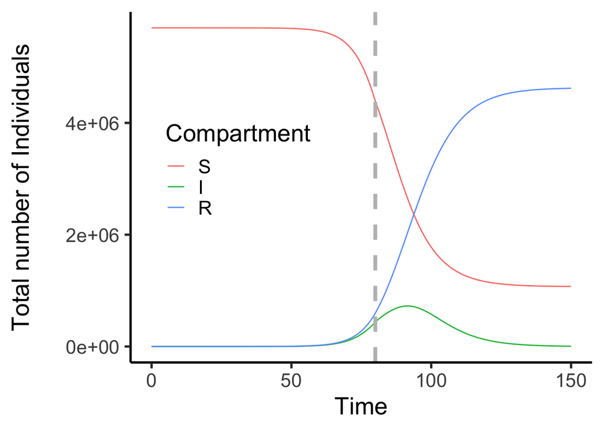

Figure 5: Simulation of the SEIR model with a shock intervention at $t_1=80$ aand reduction by 20%

```r
# initialize model
tv_mod <- tv_ode$new()
# how long to run
times <- seq(0,150)
# run the model
tv_out <- tv_mod$run(times)
# extracting data as tibble
df_tv_out <- as.data.frame(tv_out)
# plotting data
p_tv <- df_tv_out %>%
  ggplot(aes(x = t, color = name)) +
  geom_line(aes(y=S, color="S"), alpha = 0.95) +
  geom_line(aes(y=I, color="I"), alpha = 0.95) +
  geom_line(aes(y=R, color="R"), alpha = 0.95) +
  geom_vline(xintercept = 80, linetype = "dashed", color = "grey", size = 1.5) +
  scale_colour_discrete(limits = c("S", "I", "R")) +
  xlab("Time") +
  ylab("Total number of Individuals\n") +
  labs(color="Compartment") +
  theme_classic(base_size = 20) +
  theme(legend.justification = 0, legend.position = c(0.05, 0.55))
p_tv
```

**Think**

Observe the differences between the Figure 4 and Figure 5. What you think caused this? Can you change the code to see the effect of timing and reduction on the epidemic.

# Modelling Quaratine

Quarantine, generally involves separating and restricting the movement of people who may have been exposed to a contagious disease.

Let us first write the model equations for this system, assuming our base model is the one discussed in Figure 1.

**Click to reveal the ODE for the model**

$$\begin{align*}
\frac{dS}{dt} &= -\beta S I - \phi S + \psi Q \\
\frac{dI}{dt} &= \beta S I - \gamma I \\
\frac{dQ}{dt} &= \phi S - \psi Q - \epsilon Q \\
\frac{dR}{dt} &= \gamma I + \epsilon Q
\end{align*}$$

**Caution**

There can be different variations and all can be correct.

```r
sirq_ode <- odin::odin({
  # Derivatives
  deriv(S) <- -beta * S * I - phi * S + psi * Q
  deriv(I) <- beta * S * I  - gamma * I
  deriv(Q) <- phi * S - psi * Q - epsilon * Q
  deriv(R) <- gamma * I + epsilon * Q


  # Initial conditions
  initial(S) <- N_ini - I_ini
  initial(I) <- I_ini
  initial(Q) <- 0
  initial(R) <- 0

  # user defined values
  # user defined values can be given another value
  # while initializing
  N_ini <- user(5700000)
  I_ini <- user(1)

  # user defined parameters
  beta <- user(8.77e-8)
  gamma <- user(0.2)
  phi <- user(0.005)
  psi <- user(0.1)
  epsilon <- user(0.1)
})
# initialize model
sirq_mod <- sirq_ode$new()
# how long to run
times <- seq(0,150)
# run the model
sirq_out <- sirq_mod$run(times)
# extracting data as tibble
df_sirq_out <- as.data.frame(sirq_out)
# plotting data
p_sirq <- df_sirq_out %>%
  ggplot(aes(x = t, color = name)) +
  geom_line(aes(y=S, color="S"), alpha = 0.95) +
  geom_line(aes(y=I, color="I"), alpha = 0.95) +
  geom_line(aes(y=R, color="R"), alpha = 0.95) +
  geom_line(aes(y=Q, color="Q"), alpha = 0.95) +
  scale_colour_discrete(limits = c("S", "I", "R", "Q")) +
  xlab("Time") +
  ylab("Total number of Individuals\n") +
  labs(color="") +
  theme_classic(base_size = 20) +
  theme(legend.justification = 0, legend.position = c(0.05, 0.55))
p_sirq
```

[output not shown]

## References

[1]

2024. Singapore Department of Statistics (DOS). *Base*. Retrieved from https://www.singstat.gov.sg